# Angrist & Evans (1998) — Outcome Weights & Kappa Estimators

Childbearing & Labour Supply: SUW Replication, DML & Learner Comparison (N = 3,000 subsample)

Alexander Unger

14 June 2026

# Setup

## Packages & Functions

```r
# Core
library(haven)
library(AER)
library(sandwich)
library(lmtest)
library(knitr)
library(kableExtra)
# DML smoother + balance plots
library(OutcomeWeights)
library(cobalt)
library(viridis)
library(gridExtra)
library(ggplot2)
# DoubleML learners
library(DoubleML)
library(mlr3verse)

source("functions_all.R")
cat("functions_all.R sourced.\n")
```

```
## functions_all.R sourced.
```

## Data & Design

**Setting.** Angrist & Evans (1998), 1980 Census PUMS — married women aged 21–35 with two or more children. Instrument Z = `samesex` (first two children same sex); treatment D = `morekids` (more than two children); outcome Y = log family income. Controls follow the canonical AE specification: mother’s age (`agem`), age at first birth (`agefstm`), first-child-boy (`sexk`), second-child-boy (`sex2nd`), and race indicators (`blackm`, `hispm`, `othracem`). Estimation runs on the saved N = 3,000 stratified subsample (`ae98_sub.rds`); the design structure (Z/D rates, complier share, propensity surface) is preserved but point estimates are imprecise by construction and are **not** compared to the full-sample reproduction.

```r
data_path <- "/Users/alexung/Desktop/master_thesis/code/"
obj       <- readRDS(file.path(data_path, "ae98_sub.rds"))
ae98_sub  <- obj$ae98_sub

# Income sample: positive income only (subsample already income-restricted upstream,
# but re-filter to be safe and consistent with the reproduction)
ae98 <- ae98_sub[!is.na(ae98_sub$incomem) & ae98_sub$incomem > 0, ]

# Outcomes in four unit shifts (translation-invariance display, analogous to
# Card's cents/dollars). Y_dol is the working outcome everywhere else.
ae98$lincomem      <- log(ae98$incomem)              # dollars
ae98$lincomem_cnt  <- log(100    * ae98$incomem)     # cents
ae98$lincomem_ths  <- log(ae98$incomem / 1000)       # thousands
ae98$lincomem_hths <- log(ae98$incomem / 100000)     # hundred-thousands

Y_dol  <- ae98$lincomem
Y_cnt  <- ae98$lincomem_cnt
Y_ths  <- ae98$lincomem_ths
Y_hths <- ae98$lincomem_hths

Z <- as.integer(ae98$samesex)
D <- as.integer(ae98$morekids)

cat(sprintf("N (income subsample) = %d\n", nrow(ae98)))
```

```
## N (income subsample) = 3000
```

```r
cat(sprintf("mean(Z)=%.4f | mean(D)=%.4f | complier share=%.4f\n",
            mean(Z), mean(D),
            mean(D[Z==1]) - mean(D[Z==0])))
```

```
## mean(Z)=0.5020 | mean(D)=0.3493 | complier share=0.0545
```

```r
RHS <- "agem + agefstm + sexk + sex2nd + blackm + hispm + othracem"

# Kappa design matrix — WITH intercept (for logit / CBPS)
X_kappa <- model.matrix(as.formula(paste("~", RHS)), data = ae98)

# X_df for 2SLS (no intercept column)
X_df <- ae98[, c("agem","agefstm","sexk","sex2nd","blackm","hispm","othracem")]

# DML design matrix — no intercept, attributes stripped for grf (make_X)
X_dml <- make_X(as.formula(paste("~ 0 +", RHS)), data = ae98)

cat(sprintf("Kappa: %d covariates | DML: %dx%d\n",
            ncol(X_kappa) - 1, nrow(X_dml), ncol(X_dml)))
```

```
## Kappa: 7 covariates | DML: 3000x7
```

# 1. Reproduction — SUW Table

**Layout.** One treatment (more than two children), one covariate specification, four outcome-unit shifts (dollars / cents / thousands / hundred-thousands). Columns are the unit shifts. Normalized estimators (τ_cb_u, τ_ml_u, τ_ml_a10) are translation invariant — all four unit columns match; unnormalized ones (τ_ml_a, τ_ml_t, τ_ml_a0) shift with the units. With the reduced sample these reproduce the *structure* of the original table, not its point estimates.

```r
run_ae_column <- function(Y) {
  list(
    tsls  = run_2sls(Y, D, Z, X_df, endog_name = "morekids"),
    kappa = kappa_analytic_se_all(Y, Z, D, X_kappa)
  )
}

col_dol  <- run_ae_column(Y_dol)
col_cnt  <- run_ae_column(Y_cnt)
col_ths  <- run_ae_column(Y_ths)
col_hths <- run_ae_column(Y_hths)

cat("All 4 unit columns computed.\n")
```

```
## All 4 unit columns computed.
```

## Results

```r
build_unit_table(col_dol, col_cnt, col_ths, col_hths) %>%
  kbl(escape = FALSE, align = c("l","c","c","c","c"),
      caption = "SUW reproduction — Treatment: morekids. Effect of childbearing on log family income, across four income-unit shifts.") %>%
  kable_styling(bootstrap_options = c("striped","hover","condensed"),
                full_width = TRUE, font_size = 13) %>%
  add_header_above(c(" " = 1, "Income unit shift" = 4)) %>%
  pack_rows("Panel A: 2SLS (HC1-robust)",            1, 1) %>%
  pack_rows("Panel B: Normalized kappa estimators",  2, 4) %>%
  pack_rows("Panel C: Unnormalized kappa estimators",5, 7) %>%
  row_spec(2:4, background = "#eef6ff") %>%
  row_spec(5:7, background = "#fffbf0") %>%
  footnote(general = "Each cell: estimate (SE below). Blue = normalized (translation invariant: all four unit columns match). Orange = unnormalized (shift with units). Stars: * p<0.10, ** p<0.05, *** p<0.01.")
```

SUW reproduction — Treatment: morekids. Effect of childbearing on log family income, across four income-unit shifts.

| Estimator | Income unit shift dollars | Income unit shift cents | Income unit shift thousands | Income unit shift 100k |
| --- | --- | --- | --- | --- |
| **Panel A: 2SLS (HC1-robust)** |  |  |  |  |
| 2SLS | 0.428 (0.770) | 0.428 (0.770) | 0.428 (0.770) | 0.428 (0.770) |
| **Panel B: Normalized kappa estimators** |  |  |  |  |
| τ_cb_u | 0.429 (0.769) | 0.429 (0.769) | 0.429 (0.769) | 0.429 (0.769) |
| τ_ml_u | 0.429 (0.769) | 0.429 (0.769) | 0.429 (0.769) | 0.429 (0.769) |
| τ_ml_a10 | 0.474 (0.801) | 0.474 (0.801) | 0.474 (0.801) | 0.474 (0.801) |
| **Panel C: Unnormalized kappa estimators** |  |  |  |  |
| τ_ml_a | 1.326 (1.112) | 1.783 (1.394) | 0.641 (0.816) | 0.184 (0.784) |
| τ_ml_t | 1.264 (1.026) | 1.699 (1.276) | 0.611 (0.771) | 0.175 (0.748) |
| τ_ml_a0 | 1.396 (1.212) | 1.876 (1.532) | 0.674 (0.868) | 0.194 (0.824) |

Note:  
Each cell: estimate (SE below). Blue = normalized (translation invariant: all four unit columns match). Orange = unnormalized (shift with units). Stars: * p<0.10, ** p<0.05, *** p<0.01.

# 2. Double ML — PLR-IV & Wald-AIPW

```r
set.seed(42); dml_ae <- dml_with_smoother(Y_dol, D, X_dml, Z, n_cf_folds = 5, tune.parameters = "all")

res_ae <- summary(dml_ae)
```

```
##            Estimate        SE       t         p
## PLR       -0.377878  0.047674 -7.9263 3.156e-15 ***
## PLR-IV     0.131498  0.988019  0.1331    0.8941
## AIPW-ATE  -0.379711  0.048529 -7.8245 7.007e-15 ***
## Wald-AIPW  0.446080  0.413906  1.0777    0.2812
## AIPW-ATT  -0.373337  0.047917 -7.7914 9.064e-15 ***
## AIPW-ATU  -0.383133  0.051730 -7.4063 1.678e-13 ***
## ---
## Signif. codes:  0 '***' 0.001 '**' 0.01 '*' 0.05 '.' 0.1 ' ' 1
```

```r
extract_w <- function(dml_obj) {
  om <- get_outcome_weights(dml_obj)
  check_omega_rows(om)
  list(plriv    = as.vector(om$omega["PLR-IV",    ]),
       waldaipw = as.vector(om$omega["Wald-AIPW", ]))
}
w_ae <- extract_w(dml_ae)

cat("DML fit complete.\n")
```

```
## DML fit complete.
```

## Estimates

DML — morekids, Y = log family income (dollars)

| Estimator | Estimate | SE | t | p | ΣωY = τ̂ |
| --- | --- | --- | --- | --- | --- |
| PLR-IV | 0.1315 | 0.9880 | 0.1331 | 0.8941 | TRUE |
| Wald-AIPW | 0.4461 | 0.4139 | 1.0777 | 0.2812 | TRUE |

Note:  
ΣωY = τ̂: algebraic identity check (must be TRUE).

## DML vs. Kappa — Point Estimates

```r
kappa_ae <- kappa_analytic_se_all(Y_dol, Z, D, X_kappa)

cell <- function(coef, se) {
  if (is.na(coef)) return("—")
  if (is.na(se) || !is.finite(se) || se <= 0) return(sprintf("%.3f (NA)", coef))
  pval  <- 2 * pnorm(-abs(coef / se))
  stars <- ifelse(pval < 0.01, "***", ifelse(pval < 0.05, "**",
                  ifelse(pval < 0.10, "*", "")))
  sprintf("%.3f%s (%.3f)", coef, stars, se)
}

dml_cell <- function(res, est) {
  coef_val <- get_estimate(res, est)
  se_val   <- if ("SE" %in% colnames(res)) as.numeric(res[est, "SE"])
              else if ("Std. Error" %in% colnames(res)) as.numeric(res[est, "Std. Error"])
              else NA_real_
  cell(coef_val, se_val)
}

dml_rows <- rbind(
  data.frame(Estimator = "PLR-IV (DML)",
             `morekids` = dml_cell(res_ae, "PLR-IV"),
             check.names = FALSE, stringsAsFactors = FALSE),
  data.frame(Estimator = "Wald-AIPW (DML)",
             `morekids` = dml_cell(res_ae, "Wald-AIPW"),
             check.names = FALSE, stringsAsFactors = FALSE)
)

ests   <- c("tau_cb_u","tau_ml_u","tau_ml_a10","tau_ml_a","tau_ml_t","tau_ml_a0")
labels <- c("τ_cb_u","τ_ml_u","τ_ml_a10","τ_ml_a","τ_ml_t","τ_ml_a0")
kappa_rows <- do.call(rbind, lapply(seq_along(ests), function(i) {
  e <- ests[i]
  data.frame(
    Estimator = labels[i],
    `morekids` = cell(kappa_ae$estimates[e], kappa_ae$se[e]),
    check.names = FALSE, stringsAsFactors = FALSE
  )
}))

rbind(dml_rows, kappa_rows) %>%
  kbl(align = c("l","c"),
      caption = "DML vs. Kappa — Point Estimates (SE), Y = log family income (dollars)") %>%
  kable_styling(bootstrap_options = c("striped","hover","condensed"),
                full_width = TRUE, font_size = 13) %>%
  pack_rows("Double ML", 1, 2) %>%
  pack_rows("Kappa — normalized", 3, 5) %>%
  pack_rows("Kappa — unnormalized", 6, 8) %>%
  row_spec(1:2, background = "#eef6ff") %>%
  row_spec(6:8, background = "#fffbf0") %>%
  footnote(general = "Each cell: estimate (SE). Blue = DML. Orange = unnormalized kappa. Stars: * p<0.10, ** p<0.05, *** p<0.01.")
```

DML vs. Kappa — Point Estimates (SE), Y = log family income (dollars)

| Estimator | morekids |
| --- | --- |
| **Double ML** |  |
| PLR-IV (DML) | 0.131 (0.988) |
| Wald-AIPW (DML) | 0.446 (0.414) |
| **Kappa — normalized** |  |
| τ_cb_u | 0.429 (0.769) |
| τ_ml_u | 0.429 (0.769) |
| τ_ml_a10 | 0.474 (0.801) |
| **Kappa — unnormalized** |  |
| τ_ml_a | 1.326 (1.112) |
| τ_ml_t | 1.264 (1.026) |
| τ_ml_a0 | 1.396 (1.212) |

Note:  
Each cell: estimate (SE). Blue = DML. Orange = unnormalized kappa. Stars: * p<0.10, ** p<0.05, *** p<0.01.

# 3. Learner Comparison — Linear / Ranger / XGBoost

```r
make_dml_data <- function(D, X_dml) {
  df <- as.data.frame(X_dml)
  df$y <- as.numeric(Y_dol)
  df$d <- as.numeric(D)
  df$z <- as.numeric(Z)
  DoubleMLData$new(data = df, y_col = "y", d_cols = "d", z_cols = "z",
                   x_cols = colnames(X_dml))
}

dat_ae <- make_dml_data(D, X_dml)

cat("DoubleML data object built.\n")
```

```
## DoubleML data object built.
```

## Estimates

### Linear + Logistic

```r
lm_ae <- fit_iivm(dat_ae, ml_lm(), Y_dol)
learner_estimate_table(lm_ae, "Wald-AIPW — Linear + Logistic")
```

Wald-AIPW — Linear + Logistic

| Cell | Estimate | SE | ΣωY = τ̂ |
| --- | --- | --- | --- |
| morekids | NA | NA | NA |

Note:  
ΣωY = τ̂: algebraic identity check (must be TRUE).

### Ranger

```r
rf_ae <- fit_iivm(dat_ae, ml_rf(), Y_dol)
learner_estimate_table(rf_ae, "Wald-AIPW — Ranger")
```

```
## Estimates and significance testing of the effect of target variables
##   Estimate. Std. Error t value Pr(>|t|)
## d    0.5196     0.4618   1.125    0.261
```

Wald-AIPW — Ranger

| Cell | Estimate | SE | ΣωY = τ̂ |
| --- | --- | --- | --- |
| morekids | 0.5196 | 0.4618 | TRUE |

Note:  
ΣωY = τ̂: algebraic identity check (must be TRUE).

### XGBoost

```r
xgb_ae <- fit_iivm(dat_ae, ml_xgb(), Y_dol)
learner_estimate_table(xgb_ae, "Wald-AIPW — XGBoost")
```

```
## Estimates and significance testing of the effect of target variables
##   Estimate. Std. Error t value Pr(>|t|)
## d    0.9440     0.4866    1.94   0.0524 .
## ---
## Signif. codes:  0 '***' 0.001 '**' 0.01 '*' 0.05 '.' 0.1 ' ' 1
```

Wald-AIPW — XGBoost

| Cell | Estimate | SE | ΣωY = τ̂ |
| --- | --- | --- | --- |
| morekids | 0.944 | 0.4866 | FALSE |

Note:  
ΣωY = τ̂: algebraic identity check (must be TRUE).

## Comparison Table

```r
ext_cell <- function(coef, se) {
  if (is.na(coef) || !is.finite(coef)) return("—")
  if (is.na(se) || !is.finite(se) || se <= 0) return(sprintf("%.3f (NA)", coef))
  pval  <- 2 * pnorm(-abs(coef / se))
  stars <- ifelse(pval < 0.01, "***", ifelse(pval < 0.05, "**",
                  ifelse(pval < 0.10, "*", "")))
  sprintf("%.3f%s (%.3f)", coef, stars, se)
}

learner_row <- function(label, f) {
  data.frame(
    Estimator  = label,
    `morekids` = ext_cell(safe_coef(f), safe_se(f)),
    check.names = FALSE, stringsAsFactors = FALSE
  )
}

kappa_ref_row <- function(label, key) {
  data.frame(
    Estimator  = label,
    `morekids` = ext_cell(kappa_ae$estimates[key], kappa_ae$se[key]),
    check.names = FALSE, stringsAsFactors = FALSE
  )
}

rbind(
  learner_row("Wald-AIPW (linear+logit)", lm_ae),
  learner_row("Wald-AIPW (ranger)",       rf_ae),
  learner_row("Wald-AIPW (XGBoost)",      xgb_ae),
  kappa_ref_row("τ_cb_u (kappa, ref)",  "tau_cb_u"),
  kappa_ref_row("τ_ml_u (kappa, ref)",  "tau_ml_u")
) %>%
  kbl(align = c("l","c"),
      caption = "Wald-AIPW Learner Comparison — DoubleML vs. Kappa (Y = log family income, dollars)") %>%
  kable_styling(bootstrap_options = c("striped","hover","condensed"),
                full_width = TRUE, font_size = 13) %>%
  pack_rows("DoubleML learners", 1, 3) %>%
  pack_rows("Kappa reference",   4, 5) %>%
  row_spec(1:3, background = "#eef6ff") %>%
  footnote(general = "Each cell: estimate (SE). Blue = DoubleML. All score='LATE', n_folds=5. Stars: * p<0.10, ** p<0.05, *** p<0.01.")
```

```
## Estimates and significance testing of the effect of target variables
##   Estimate. Std. Error t value Pr(>|t|)
## d    0.5196     0.4618   1.125    0.261
##
##
## Estimates and significance testing of the effect of target variables
##   Estimate. Std. Error t value Pr(>|t|)
## d    0.9440     0.4866    1.94   0.0524 .
## ---
## Signif. codes:  0 '***' 0.001 '**' 0.01 '*' 0.05 '.' 0.1 ' ' 1
```

Wald-AIPW Learner Comparison — DoubleML vs. Kappa (Y = log family income, dollars)

| Estimator | morekids |
| --- | --- |
| **DoubleML learners** |  |
| Wald-AIPW (linear+logit) | — |
| Wald-AIPW (ranger) | 0.520 (0.462) |
| Wald-AIPW (XGBoost) | 0.944* (0.487) |
| **Kappa reference** |  |
| τ_cb_u (kappa, ref) | 0.429 (0.769) |
| τ_ml_u (kappa, ref) | 0.429 (0.769) |

Note:  
Each cell: estimate (SE). Blue = DoubleML. All score=‘LATE’, n_folds=5. Stars: * p<0.10, ** p<0.05, *** p<0.01.

# 4. Weight Diagnostics

## DML vs. Kappa

```r
style_dml_diag(dml_diag_cell(w_ae, kw_ae), "Weight Diagnostics — DML vs. Kappa | morekids")
```

Weight Diagnostics — DML vs. Kappa | morekids

| Estimator | Sum_w | ESS | ESS_mod | Pct_neg | Max_abs_w |
| --- | --- | --- | --- | --- | --- |
| PLR-IV (DML) | 0.0000000 | 2 | 2006 | 49.8 | 0.055201 |
| Wald-AIPW (DML) | 0.0000000 | 3 | 2991 | 49.8 | 0.013690 |
| τ_cb_u (kappa) | 0.0000000 | 3 | 2989 | 49.8 | 0.013037 |
| τ_ml_u (kappa) | 0.0000000 | 3 | 2989 | 49.8 | 0.013043 |
| τ_ml_a10 (kappa) | 0.0000000 | 2 | 2982 | 49.8 | 0.013888 |
| τ_ml_a (kappa) | 0.0992064 | 3 | 2989 | 49.8 | 0.013198 |
| τ_ml_t/a1 (kappa) | 0.0945271 | 3 | 2989 | 49.8 | 0.012576 |
| τ_ml_a0 (kappa) | 0.1043953 | 2 | 2989 | 49.8 | 0.013888 |

Note:  
Blue = DML. Sum_w ≈ 0 ⟺ translation invariant. ESS_mod = (Σ|ω|)²/Σω² (report this); ESS = 1/Σω² (reference only).

## Learners vs. Kappa

```r
style_ext_diag(ext_diag_block(kw_ae, lm_ae$w, rf_ae$w, xgb_ae$w),
               "Weight Diagnostics — Learners | morekids")
```

Weight Diagnostics — Learners | morekids

| Estimator | Sum_w | ESS | ESS_mod | Pct_neg | Max_abs_w |
| --- | --- | --- | --- | --- | --- |
| Wald-AIPW (linear+logit) | NA | NA | NA | NA | NA |
| Wald-AIPW (ranger) | 0.0000000 | 3 | 2987 | 49.8 | 0.017949 |
| Wald-AIPW (XGBoost) | 0.0012029 | 2 | 2552 | 49.7 | 0.053952 |
| τ_cb_u (kappa, CBPS) | 0.0000000 | 3 | 2989 | 49.8 | 0.013037 |
| τ_ml_u (kappa, MLE) | 0.0000000 | 3 | 2989 | 49.8 | 0.013043 |
| τ_ml_a10 (kappa, MLE) | 0.0000000 | 2 | 2982 | 49.8 | 0.013888 |
| τ_ml_a (kappa, unnorm) | 0.0992064 | 3 | 2989 | 49.8 | 0.013198 |
| τ_ml_t (kappa, unnorm) | 0.0945271 | 3 | 2989 | 49.8 | 0.012576 |
| τ_ml_a0 (kappa, unnorm) | 0.1043953 | 2 | 2989 | 49.8 | 0.013888 |

Note:  
Blue = DoubleML learners. ESS_mod = (Σ|ω|)²/Σω² (report this); ESS = 1/Σω² (reference only). NA rows = learner produced no weights.

## Weight-Statistics Bridge — RQ1

**What this is.** For every estimator, `weight_bridge()` reports the outcome weights **Overall / Treated / Control** (control sign-flipped, matching Knaus’s convention), putting the two diagnostic vocabularies side by side: his six `summary()` statistics (Min, Max, %Neg, Σ of the largest 10%, Σω, Σ|ω|) next to the two effective-sample-size measures (Kish vs. modified). The headline is **ESS mod**. The Knaus block is computed in plain R, so the kappa estimators get his statistics too, which his package never produces for them.

### ESS overview (Kish vs. modified)

```r
ess_overview_df %>%
  kbl(caption = "Effective sample size, Overall scope — Kish (1/Σω²) vs. modified ((Σ|ω|)²/Σω²)",
      col.names = c("Estimator","ESS Kish","ESS mod"),
      align = c("l","r","r")) %>%
  kable_styling(bootstrap_options = c("striped","hover","condensed"),
                full_width = TRUE, font_size = 13) %>%
  column_spec(3, bold = TRUE, background = "#eef6ff") %>%
  footnote(general = "Where Kish collapses toward 1, the modified ESS recovers the genuine usable weight mass. Report the modified column.")
```

Effective sample size, Overall scope — Kish (1/Σω²) vs. modified ((Σ|ω|)²/Σω²)

| Estimator | ESS Kish | ESS mod |
| --- | --- | --- |
| PLR-IV (DML) | 2 | 2006 |
| Wald-AIPW (DML) | 3 | 2991 |
| Ranger | 3 | 2987 |
| XGBoost | 2 | 2552 |
| τ_cb_u (kappa) | 3 | 2989 |
| τ_ml_u (kappa) | 3 | 2989 |
| τ_ml_t (kappa) | 3 | 2989 |

Note:  
Where Kish collapses toward 1, the modified ESS recovers the genuine usable weight mass. Report the modified column.

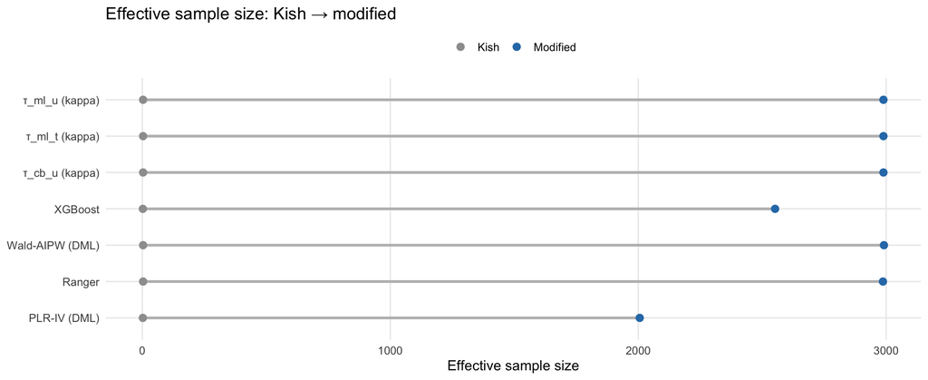

```r
ggplot(ess_overview_df, aes(y = Estimator)) +
  geom_segment(aes(x = ESS_kish, xend = ESS_mod, yend = Estimator),
               colour = "#bdbdbd", linewidth = 1.1) +
  geom_point(aes(x = ESS_kish, colour = "Kish"),     size = 2.6) +
  geom_point(aes(x = ESS_mod,  colour = "Modified"), size = 2.6) +
  scale_colour_manual(values = c("Kish" = "#9e9e9e", "Modified" = "#2c7bb6"), name = NULL) +
  labs(title = "Effective sample size: Kish → modified",
       x = "Effective sample size", y = NULL) +
  theme_minimal(base_size = 12) +
  theme(legend.position = "top", panel.grid.minor = element_blank())
```

### Full bridge table

```r
bridge_table(bridge_w, D, "Weight-statistics bridge — morekids")
```

Weight-statistics bridge — morekids

| Scope | Knaus summary() statistics Min | Knaus summary() statistics Max | Knaus summary() statistics %Neg | Knaus summary() statistics ΣTop10% | Knaus summary() statistics Σω | Knaus summary() statistics Σ\|ω\| | Effective sample size ESS Kish | Effective sample size ESS mod |
| --- | --- | --- | --- | --- | --- | --- | --- | --- |
| **PLR-IV (DML)** |  |  |  |  |  |  |  |  |
| Overall | -0.0552006 | 0.0416137 | 49.8 | 6.887295 | 0.0000000 | 33.43981 | 2 | 2006 |
| Treated | -0.0465620 | 0.0416137 | 45.9 | 2.463431 | 1.2787748 | 11.29722 | 6 | 722 |
| Control | -0.0371203 | 0.0552006 | 48.1 | 5.076923 | 1.2787748 | 22.14259 | 3 | 1288 |
| **Wald-AIPW (DML)** |  |  |  |  |  |  |  |  |
| Overall | -0.0136904 | 0.0136344 | 49.8 | 3.710662 | 0.0000000 | 34.29707 | 3 | 2991 |
| Treated | -0.0132653 | 0.0135729 | 45.9 | 1.308713 | 0.9702241 | 11.96885 | 7 | 1045 |
| Control | -0.0136344 | 0.0136904 | 48.1 | 2.424551 | 0.9702241 | 22.32822 | 4 | 1946 |
| **Ranger** |  |  |  |  |  |  |  |  |
| Overall | -0.0179488 | 0.0159258 | 49.8 | 3.753335 | 0.0000000 | 34.50791 | 3 | 2987 |
| Treated | -0.0169856 | 0.0158314 | 45.9 | 1.326499 | 0.9827889 | 12.04116 | 7 | 1043 |
| Control | -0.0159258 | 0.0179488 | 48.1 | 2.506077 | 0.9827889 | 22.46675 | 4 | 1943 |
| **XGBoost** |  |  |  |  |  |  |  |  |
| Overall | -0.0539517 | 0.0383622 | 49.7 | 5.375187 | 0.0012029 | 32.80015 | 2 | 2552 |
| Treated | -0.0438255 | 0.0347652 | 45.8 | 1.937126 | 0.9624217 | 11.52626 | 7 | 892 |
| Control | -0.0383622 | 0.0539517 | 48.2 | 3.497596 | 0.9612187 | 21.27389 | 4 | 1660 |
| **τ_cb_u (kappa)** |  |  |  |  |  |  |  |  |
| Overall | -0.0130367 | 0.0126934 | 49.8 | 3.725582 | 0.0000000 | 33.83958 | 3 | 2989 |
| Treated | -0.0127264 | 0.0126934 | 45.9 | 1.310922 | 1.0000000 | 11.81859 | 7 | 1044 |
| Control | -0.0126934 | 0.0130367 | 48.1 | 2.322433 | 1.0000000 | 22.02100 | 4 | 1945 |
| **τ_ml_u (kappa)** |  |  |  |  |  |  |  |  |
| Overall | -0.0130425 | 0.0126958 | 49.8 | 3.726698 | 0.0000000 | 33.85508 | 3 | 2989 |
| Treated | -0.0127344 | 0.0126958 | 45.9 | 1.311292 | 1.0000000 | 11.82416 | 7 | 1044 |
| Control | -0.0126958 | 0.0130425 | 48.1 | 2.323119 | 1.0000000 | 22.03092 | 4 | 1945 |
| **τ_ml_t (kappa)** |  |  |  |  |  |  |  |  |
| Overall | -0.0125755 | 0.0123121 | 49.8 | 3.614069 | 0.0945271 | 32.73738 | 3 | 2989 |
| Treated | -0.0122785 | 0.0123121 | 45.9 | 1.271662 | 1.0000000 | 11.43658 | 8 | 1044 |
| Control | -0.0123121 | 0.0125755 | 48.1 | 2.239937 | 0.9054729 | 21.30080 | 4 | 1945 |

Note:  
Control rows use Knaus’s sign-flipped −ω convention. ESS mod = (Σ|ω|)²/Σω² is the number to report; ESS Kish = 1/Σω² is reference only.

# 5. Love Plots

## DML vs. Kappa (all 8 estimators)

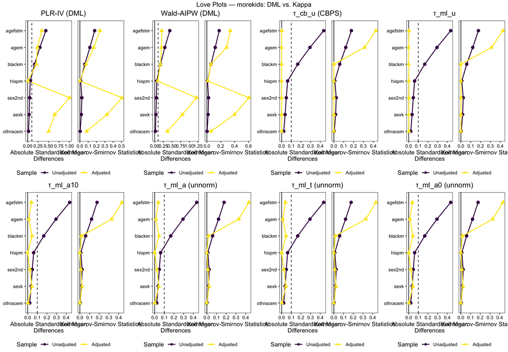

```r
grobs <- Filter(Negate(is.null), list(
  maybe_love("PLR-IV (DML)",     w_ae$plriv,       D, X_dml),
  maybe_love("Wald-AIPW (DML)",  w_ae$waldaipw,    D, X_dml),
  maybe_love("τ_cb_u (CBPS)",    kw_ae$tau_cb_u,   D, X_dml),
  maybe_love("τ_ml_u",           kw_ae$tau_ml_u,   D, X_dml),
  maybe_love("τ_ml_a10",         kw_ae$tau_ml_a10, D, X_dml),
  maybe_love("τ_ml_a (unnorm)",  kw_ae$tau_ml_a,   D, X_dml),
  maybe_love("τ_ml_t (unnorm)",  kw_ae$tau_ml_a1,  D, X_dml),
  maybe_love("τ_ml_a0 (unnorm)", kw_ae$tau_ml_a0,  D, X_dml)
))
grid.arrange(grobs = grobs, nrow = 2, top = "Love Plots — morekids: DML vs. Kappa")
```

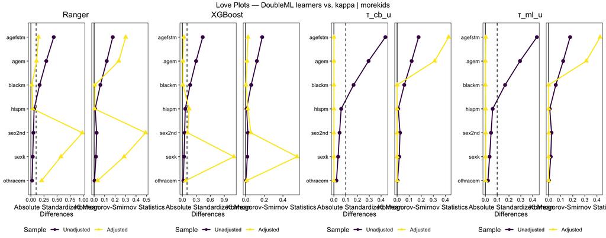

```r
grobs <- Filter(Negate(is.null), list(
  maybe_love("Linear+Logit", lm_ae$w,        D, X_dml),
  maybe_love("Ranger",       rf_ae$w,        D, X_dml),
  maybe_love("XGBoost",      xgb_ae$w,       D, X_dml),
  maybe_love("τ_cb_u",       kw_ae$tau_cb_u, D, X_dml),
  maybe_love("τ_ml_u",       kw_ae$tau_ml_u, D, X_dml)
))
grid.arrange(grobs = grobs, nrow = 1, top = "Love Plots — DoubleML learners vs. kappa | morekids")
```